# Introduction

> This project involved analysis of Twitter account of # we rate dogs. This account posts wonderful articles about dogs and is essentially a desert for pet-lovers. I downloaded data from multiple sources, cleaned up the data and stored it in a master file and here I am going to analyse it all and provide a short summary for the project

```python
# lets download all the essential packages here
import numpy as np
import pandas as pd
import matplotlib as plt
import seaborn as sns
% matplotlib inline
from PIL import Image
import requests
import datetime
```

```python
# let us read the masterfile into a dataframe using pandas
masterdf = pd.read_csv('twitter_archive_master.csv')
```

```python
#let us have a look at the masterdf
masterdf.info()
```

```
<class 'pandas.core.frame.DataFrame'>
RangeIndex: 1981 entries, 0 to 1980
Data columns (total 10 columns):
tweet_id                1981 non-null int64
Date_of_tweet           1981 non-null object
source                  1981 non-null object
favorite_count          1981 non-null int64
retweet_count           1981 non-null int64
Dog_image               1981 non-null object
Prediction_Dog_Breed    1981 non-null object
Dog_stage               1981 non-null object
hour_of_day             1981 non-null int64
rating                  1981 non-null int64
dtypes: int64(5), object(5)
memory usage: 154.8+ KB
```

```python
# It seems date-of_tweet format needs to be changed again
masterdf['Date_of_tweet']=masterdf.Date_of_tweet.apply(lambda x:datetime.datetime.strptime(x, "%Y-%m-%d"))
masterdf.info()
```

```
<class 'pandas.core.frame.DataFrame'>
RangeIndex: 1981 entries, 0 to 1980
Data columns (total 10 columns):
tweet_id                1981 non-null int64
Date_of_tweet           1981 non-null datetime64[ns]
source                  1981 non-null object
favorite_count          1981 non-null int64
retweet_count           1981 non-null int64
Dog_image               1981 non-null object
Prediction_Dog_Breed    1981 non-null object
Dog_stage               1981 non-null object
hour_of_day             1981 non-null int64
rating                  1981 non-null int64
dtypes: datetime64[ns](1), int64(5), object(4)
memory usage: 154.8+ KB
```

```python
# let us look at how the entires look
masterdf.head(2)
```

|  | tweet_id | Date_of_tweet | source | favorite_count | retweet_count | Dog_image | Prediction_Dog_Breed | Dog_stage | hour_of_day | rating |
| --- | --- | --- | --- | --- | --- | --- | --- | --- | --- | --- |
| 0 | 892420643555336193 | 2017-08-01 | Twitter for iPhone | 38826 | 8594 | https://pbs.twimg.com/media/DGKD1-bXoAAIAUK.jpg | orange | None | 16 | 13 |
| 1 | 892177421306343426 | 2017-08-01 | Twitter for iPhone | 33259 | 6316 | https://pbs.twimg.com/media/DGGmoV4XsAAUL6n.jpg | Chihuahua | None | 0 | 13 |

# Analysis

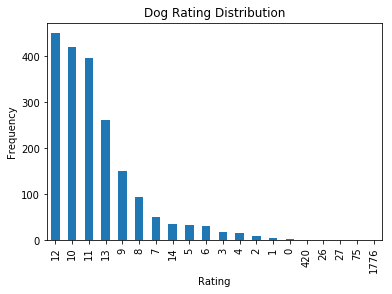

```python
# let us see how the favorite count looks like
masterdf.rating.value_counts()
ax = masterdf['rating'].value_counts().plot(kind='bar', title='Dog Rating Distribution');
ax.set_xlabel("Rating")
ax.set_ylabel("Frequency");
```

> It seems the most popular rating is 12 and then their are a few outliers like 420, 1716 which are very interesting, given 1776 is the American independence year. So lets explore this rating more

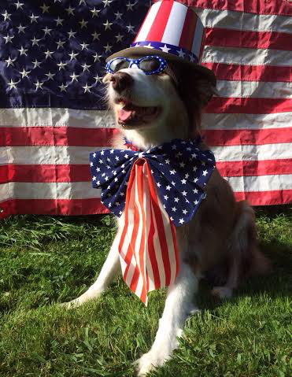

```python
# let us read the contents of the image
url = masterdf[masterdf['rating']==1776]['Dog_image'].iloc[0]
Image.open(requests.get(url, stream=True).raw)
```

```python
# Interestingly, it seems this dog dressed up for the American Independence Day.
# Let us see how many favorite and retweet count this tweet got
masterdf[masterdf['rating']==1776]
```

|  | tweet_id | Date_of_tweet | source | favorite_count | retweet_count | Dog_image | Prediction_Dog_Breed | Dog_stage | hour_of_day | rating |
| --- | --- | --- | --- | --- | --- | --- | --- | --- | --- | --- |
| 723 | 749981277374128128 | 2016-07-04 | TweetDeck | 5514 | 2712 | https://pbs.twimg.com/media/CmgBZ7kWcAAlzFD.jpg | bow_tie | None | 15 | 1776 |

```python
# Now let us look at the maximum values of all columns
masterdf.max()
```

```
tweet_id                                               892420643555336193
Date_of_tweet                                         2017-08-01 00:00:00
source                                                 Twitter for iPhone
favorite_count                                                     143493
retweet_count                                                       77411
Dog_image               https://pbs.twimg.com/tweet_video_thumb/CeBym7...
Prediction_Dog_Breed                                                zebra
Dog_stage                                              puppodoggoNoneNone
hour_of_day                                                            23
rating                                                               1776
dtype: object
```

> Though for some columns the max does not make sense, but let us analyse it for favorite_count and retweet_count. Those are really high numbers. I am interested to see how these favorite and retweet counts change over time. How do they look when plotted together. So let's plot the favorite and retweet count

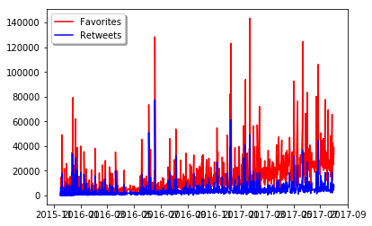

```python
# let us look at a how retweet_count and favorite_count have changed over time
import matplotlib.pyplot as plt
plt.plot(masterdf['Date_of_tweet'],masterdf['favorite_count'], 'r', label='Favorites')
plt.plot(masterdf['Date_of_tweet'],masterdf['retweet_count'], 'b', label='Retweets')
legend = plt.legend(loc='upper left', shadow=True)
plt.show()
# masterdf.plot('Date_of_tweet','favorite_count','Date_of_tweet','retweet_count');
```

> This plot is very interesting. It seems the favorite and retweet count have similar shape. Let us find out the correlation betwen the two to confirm this

```python
data = masterdf[['favorite_count','retweet_count']]
correlation = data.corr(method='pearson')
correlation
```

|  | favorite_count | retweet_count |
| --- | --- | --- |
| favorite_count | 1.000000 | 0.917317 |
| retweet_count | 0.917317 | 1.000000 |

> This is interesting. It seems there is a very high correlation between favorite and retweet count

```
Twitter for iPhone    1942
Twitter Web Client      28
TweetDeck               11
Name: source, dtype: int64
```

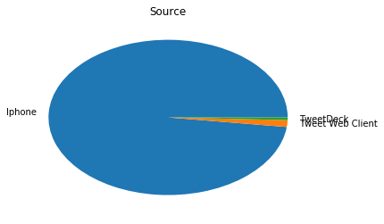

```python
# let us look at the source of these twitter's
plt.title('Source')
plt.pie(masterdf['source'].value_counts(), labels=['Iphone','Tweet Web Client','TweetDeck']);
#masterdf['source'].valume_counts().plot(kind='pie', title='Source');
masterdf.source.value_counts()
```

# Summary

We rate Dogs is a very interesting twitter account. They rate dogs out of 10 and most of the dogs get rating more than 10. Sometimes, they give funny rating such as on the independence day. The tweets have been retweeted and liked as a favorite a lot. Most tweets that are retweeted more are also liked more, as is evident from the high correlation between the 2 factors. Most tweets are posted through Iphone app of twitter. Some others that are used are Tweet deck and tweet web client.